# Part 2: Digging Deeper into Python Programming Constructs

## Overview of Part 2

## Highlights from Part 1

### 1. Python has a notion of environments which enacapsulate the interpreter and a set of package

### 2. Python syntax is distinct from, but not unrelated to R

### 3. Most of the time we’ve call functions with `function(object)` but sometimes it’s been `object.function()` (as with copy). We’ll talk more about this later.

### 4. Zero indexing.

## Topics for this part

### 1. Packages

### 2. Numeric computing with Numpy.

### 3. Using Objects

### 3. Generators

## Packages

## Python is “batteries not included”

R includes *a lot* of computing facilities with the core language.

1. Plotting
2. Vectors, matrices, and arrays
3. Optimized and vectorized linear algebra routines
4. Suite of statistical functions and models
5. `data.frame`s

None of these are included with Python.

## Python Virtual Environments and Package Management

This class uses virtualenv to create an environment and pip3 within the environment to add packages. Packages are install from [PyPI](https://pypi.org/).

[Anaconda](https://www.anaconda.com/) is another option for both creating environments and adding packages from [Anaconda Cloud](https://anaconda.org/anaconda/repo). It is an environment and package manager, not just for Python. There is an R installation, I have heard only bad things about this build.

## What’s with the emphasis on environments?

Development culture is different than R’s

- R community (CRAN maintainers) place a higher value on package user’s time by enforcing *downstream dependencies*. This is the reason R’s `install.packages()` function “just works”. It does a better job of hiding analysts from package development.
- Python community places higher value on developer time. It is often up to the user to sort out compatibility problems between packages. This became a big enough issue that companies, like [Continuum Analytics](http://www.continuumanalytics.com/), began creating pre-packaged virtual environments.

Result is that R users use environments (with `packrat`, `switchr`, `renv`) for reproducibility, Python users use them for reproducibility and package compatibility.

## A second look at setup-p4rp.sh

```bash
# Make sure python 3 and pip3 are installed on you machine and accessible from the
# command line.

# Install virtualenv.
pip3 install virtualenv

# Create a "python for R programmer's" virtual environment.
virtualenv -p python3 p4rp

# Activate the virtual environment. Note: this works for Mac and Linux.
source p4rp/bin/activate

# The following *may* work on Windows.
# p4rp\bin\activate.bat

# Install the needed packages.
pip3 install numpy pandas seaborn plotnine
```

## Numeric Computing

Python doesn’t have a built-in notion of vectorized operations.

```python
# Python
list(range(10)) + 1
```

```
## Error in py_call_impl(callable, dots$args, dots$keywords): TypeError: can only concatenate list (not "int") to list
##
## Detailed traceback:
##   File "<string>", line 1, in <module>
```

We can perform this with list comprehensions.

```python
# Python
print( [x + 1 for x in list(range(10))] )
```

```
## [1, 2, 3, 4, 5, 6, 7, 8, 9, 10]
```

Or, we could create a method for adding values to lists, but it’s already been done.

## Importing the `numpy` Package

```python
# Python
import numpy
print( numpy.arange(10) + 1 )
```

```
## [ 1  2  3  4  5  6  7  8  9 10]
```

```python
# Python
from numpy import *
print( arange(10) + 1 )
```

```
## [ 1  2  3  4  5  6  7  8  9 10]
```

```python
# Python
import numpy as np
print( np.arange(10) + 1 )
```

```
## [ 1  2  3  4  5  6  7  8  9 10]
```

## It’s all arrays

Numpy doesn’t distinguish vectors, matrices, and arrays.

```python
# Python

# A vector
vec = np.array(list(range(12)))
print(vec)

# A matrix
```

```
## [ 0  1  2  3  4  5  6  7  8  9 10 11]
```

```python
mat = np.array( [ [1, 2, 3], [4, 5, 6], [7, 8, 9], [10, 11, 12] ] )
print(mat)
```

```
## [[ 1  2  3]
##  [ 4  5  6]
##  [ 7  8  9]
##  [10 11 12]]
```

## It’s all arrays (cont’d)

```python
# Python

tensor3 = np.array( [ [[1, 2], [3, 4]], [[5, 6], [7,8]] ])
print(tensor3)
```

```
## [[[1 2]
##   [3 4]]
##
##  [[5 6]
##   [7 8]]]
```

## What is the dimension of a numpy array?

```python
# Python
print(vec.shape)
```

```
## (12,)
```

```python
print(mat.shape)
```

```
## (4, 3)
```

```python
print(tensor3)
```

```
## [[[1 2]
##   [3 4]]
##
##  [[5 6]
##   [7 8]]]
```

## How are values stored?

Check the `dtype`.

```python
# Python

tensor3.dtype
```

```
## dtype('int64')
```

```python
double(tensor3).dtype
```

```
## dtype('float64')
```

```python
np.array([str(x) for x in mat.flatten().tolist()], dtype = str).reshape(4, 3)
```

```
## array([['1', '2', '3'],
##        ['4', '5', '6'],
##        ['7', '8', '9'],
##        ['10', '11', '12']], dtype='<U2')
```

## What other information is stored in a numpy array?

```python
# Python

vec_slots = dir(vec)
len(vec_slots)
```

```
## 162
```

```python
print( [vec_slots[-i] for i in range(1, 51)] )
```

```
## ['view', 'var', 'transpose', 'trace', 'tostring', 'tolist', 'tofile', 'tobytes', 'take', 'swapaxes', 'sum', 'strides', 'std', 'squeeze', 'sort', 'size', 'shape', 'setflags', 'setfield', 'searchsorted', 'round', 'resize', 'reshape', 'repeat', 'real', 'ravel', 'put', 'ptp', 'prod', 'partition', 'no…
```

## What else is in numpy?

```python
# Python

np_objects = dir(np)
len(np_objects)
```

```
## 621
```

```python
print( [np_objects[i] for i in range(70)] )
```

```
## ['ALLOW_THREADS', 'AxisError', 'BUFSIZE', 'CLIP', 'ComplexWarning', 'DataSource', 'ERR_CALL', 'ERR_DEFAULT', 'ERR_IGNORE', 'ERR_LOG', 'ERR_PRINT', 'ERR_RAISE', 'ERR_WARN', 'FLOATING_POINT_SUPPORT', 'FPE_DIVIDEBYZERO', 'FPE_INVALID', 'FPE_OVERFLOW', 'FPE_UNDERFLOW', 'False_', 'Inf', 'Infinity', 'M…
```

## Array Indexing

```r
# R

mat <- t(matrix(seq_len(12), ncol = 4))
mat
```

```
##      [,1] [,2] [,3]
## [1,]    1    2    3
## [2,]    4    5    6
## [3,]    7    8    9
## [4,]   10   11   12
```

```r
mat[1:2, 1:3]
```

```
##      [,1] [,2] [,3]
## [1,]    1    2    3
## [2,]    4    5    6
```

## Array Indexing (cont’d)

```python
# Python

mat[:2, :3]
```

```
## array([[1, 2, 3],
##        [4, 5, 6]])
```

```python
mat[1:3, :3]
```

```
## array([[4, 5, 6],
##        [7, 8, 9]])
```

```python
mat[ [0, 3, 2], :]
```

```
## array([[ 1,  2,  3],
##        [10, 11, 12],
##        [ 7,  8,  9]])
```

## Boolean Indexing

```r
# R

mat > 2
```

```
##       [,1]  [,2] [,3]
## [1,] FALSE FALSE TRUE
## [2,]  TRUE  TRUE TRUE
## [3,]  TRUE  TRUE TRUE
## [4,]  TRUE  TRUE TRUE
```

```r
mat[mat > 2]
```

```
##  [1]  4  7 10  5  8 11  3  6  9 12
```

## Boolean Indexing (cont’d)

```python
# Python

mat > 2
```

```
## array([[False, False,  True],
##        [ True,  True,  True],
##        [ True,  True,  True],
##        [ True,  True,  True]])
```

```python
mat[mat > 2]
```

```
## array([ 3,  4,  5,  6,  7,  8,  9, 10, 11, 12])
```

## Fitting Ordinary Least Squares

Recall the formula for fitting the ordinary least squares model:

\[ \begin{align} \widehat{\beta} &= (X^T \ X)^{-1} \ X^T \ Y. \\ \end{align} \] Letting \(X = QR\) where \(Q^TQ = I\) and \(R\) is upper right triangular we can rewrite as:

\[ \begin{align} \widehat{\beta} &= ( (QR) ^T\ QR) ^{-1} \ (Q R)^{T} \ Y \\ &= (QR)^{-1} \ ((QR)^T )^{-1} \ (Q R)^{T} \ Y \\ &= (QR)^{-1} \ Y \\ &= R^{-1} Q^T Y \end{align} \] to create a *numerically stable*, if not limited, implementation of OLS.

## Our implementation

```python
# Python

import seaborn as sns # for iris

def ols(Y, X):
    q, r = np.linalg.qr(X)
    return(np.linalg.inv( r ).dot( q.T ).dot( Y ))

iris = sns.load_dataset("iris")
iris_mat = iris[["sepal_width", "petal_length", "petal_width"]].values

print(ols(iris['sepal_length'].values, iris_mat))
```

```
## [ 1.12106169  0.92352887 -0.89567583]
```

## Our implementation (cont’d)

```r
fit <- lm(Sepal.Length ~ Sepal.Width + Petal.Length + Petal.Width - 1,
          data = iris)
fit$coefficients
```

```
##  Sepal.Width Petal.Length  Petal.Width
##    1.1210617    0.9235289   -0.8956758
```

## Using Objects to Visualize Data

## Object Oriented Programming

You’ve already been making use of Python’s object oriented functionality.

- `list_vals.copy()`
- `np.linalg.inv( r ).dot( q.T )`

In each case you were accessing data or calling a function called a (method) associated with an object using the `.` operator.

Packages are themselves object.

### An *object* contains data (called attributes or fields) and methods (functions).

An object *has* attributes and can do things with methods.

An object is an *instance* of a class.

- `np` is an instance of type `Module`.
- `list_vals` is an instance of type `list`.

## A Primitive Vector Object in R

```r
# R

vec_vals <- list(
  vals = 1:10,
  add_one = function(vec_vals) {
    vec_vals$vals <- vec_vals$vals + 1
    vec_vals
  }
)

print(vec_vals)
```

```
## $vals
##  [1]  1  2  3  4  5  6  7  8  9 10
##
## $add_one
## function(vec_vals) {
##     vec_vals$vals <- vec_vals$vals + 1
##     vec_vals
##   }
```

## A Primitive Vector Object in R (cont’d)

```r
# R
print(vec_vals$add_one(vec_vals))
```

```
## $vals
##  [1]  2  3  4  5  6  7  8  9 10 11
##
## $add_one
## function(vec_vals) {
##     vec_vals$vals <- vec_vals$vals + 1
##     vec_vals
##   }
```

Note two differences:

1. Python uses `.` instead of our `$`.
2. The calling object is invisibly passes as the first argument.

## Plotting with Objects

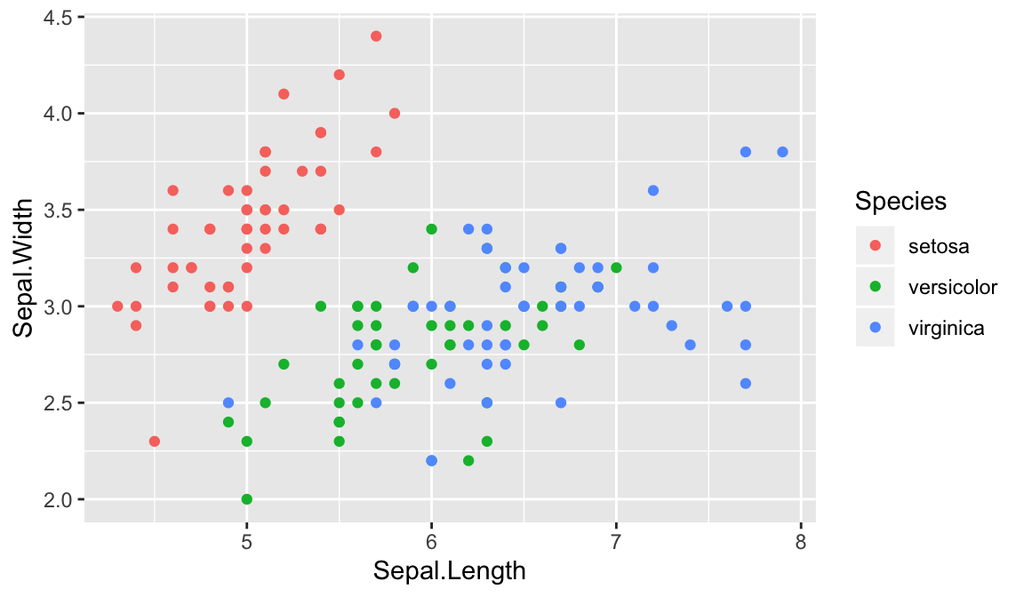

```r
# R

library(ggplot2)

ggplot(iris, aes(x = Sepal.Length, y = Sepal.Width, color = Species)) +
  geom_point()
```

## Plotting with Objects

```python
# Python

import plotnine
from plotnine import *

plotnine.options.figure_size = (2, 1)

ggplot(iris, aes(x = "sepal_length", y = "sepal_width", color = "species")) +\
  geom_point() + theme(subplots_adjust={'right': .7})
```

## Plotting with Objects (cont’d)

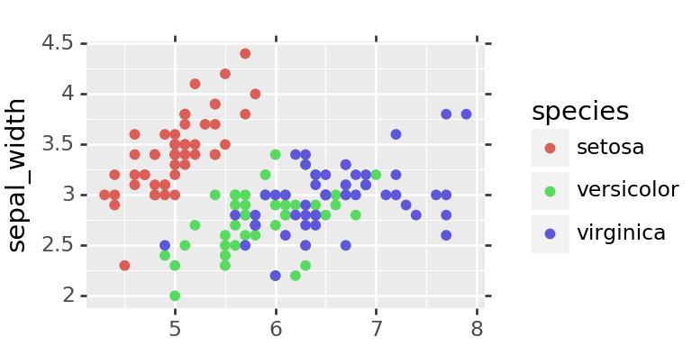

## What’s with `+\`

### Python expects something to the left and right of `+\`.

### It can’t find the second argument on the second line.

### So we need to tell the interpreter to look at the next line with `\`.

### Alternative is to wrap the entire statement in `()`

```python
(ggplot(iris, aes(x = "sepal_length", y = "sepal_width", color = "species")) +
    geom_point() + theme(subplots_adjust={'right': .7}))
```

## Where are the objects?

The `ggplot` function creates an object of type `ggplot`.

```python
# Python

p = ggplot(iris, aes(x = "sepal_length", y = "sepal_width", color = "species"))
type(p)
```

```
## <class 'plotnine.ggplot.ggplot'>
```

## Where are the methods?

`+` is an *infix operator*

- a function where the first argument is on the left of the operator and the second is on the right
- it is implemented via the `__add__` method.

```python
# Python

dir(p)
```

```
## ['__add__', '__class__', '__deepcopy__', '__delattr__', '__dict__', '__dir__', '__doc__', '__eq__', '__format__', '__ge__', '__getattribute__', '__gt__', '__hash__', '__iadd__', '__init__', '__init_subclass__', '__le__', '__lt__', '__module__', '__ne__', '__new__', '__reduce__', '__reduce_ex__', …
```

## We can call `__add__` with `.`

```python
# Python

p = ggplot(iris, aes(x = "sepal_length", y = "sepal_width", color = "species"))

geom = geom_point()
type(geom)
```

```
## <class 'plotnine.geoms.geom_point.geom_point'>
```

```python
theme_change = theme(subplots_adjust={'right': .7})

# Note that __add__ creates copies.
p = p.__add__(geom)
p = p.__add__(theme_change)
```

## We can call `__add__` with `.` (cont’d)

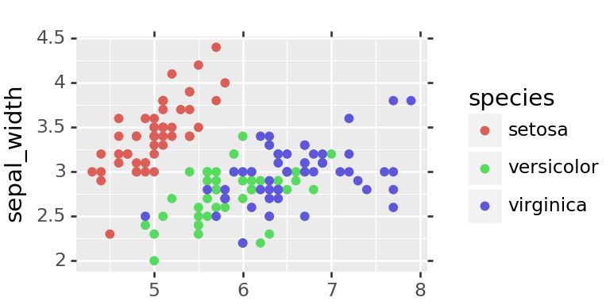

```python
# Python

p.draw()
```